# United Nations dataset study - Regression Course

Description

Let’s first load the different packages needed for this exercice

```r
library(alr4)
library(dplyr)
library(ggplot2)
```

Loading and getting the structure of the data :

```r
DB <- alr4::UN11
str(DB)
```

```
'data.frame':   199 obs. of  6 variables:
 $ region   : Factor w/ 8 levels "Africa","Asia",..: 2 4 1 1 3 5 2 3 8 4 ...
 $ group    : Factor w/ 3 levels "oecd","other",..: 2 2 3 3 2 2 2 2 1 1 ...
 $ fertility: num  5.97 1.52 2.14 5.13 2 ...
 $ ppgdp    : num  499 3677 4473 4322 13750 ...
 $ lifeExpF : num  49.5 80.4 75 53.2 81.1 ...
 $ pctUrban : num  23 53 67 59 100 93 64 47 89 68 ...
 - attr(*, "na.action")=Class 'omit'  Named int [1:34] 4 5 8 28 41 67 68 72 79 83 ...
  .. ..- attr(*, "names")= chr [1:34] "Am Samoa" "Andorra" "Antigua and Barbuda" "Br Virigin Is" ...
```

```r
#View(DB)
head(DB)
```

|  | region | group | fertility | ppgdp | lifeExpF | pctUrban |
| --- | --- | --- | --- | --- | --- | --- |
| Afghanistan | Asia | other | 5.968 | 499.0 | 49.49 | 23 |
| Albania | Europe | other | 1.525 | 3677.2 | 80.40 | 53 |
| Algeria | Africa | africa | 2.142 | 4473.0 | 75.00 | 67 |
| Angola | Africa | africa | 5.135 | 4321.9 | 53.17 | 59 |
| Anguilla | Caribbean | other | 2.000 | 13750.1 | 81.10 | 100 |
| Argentina | Latin Amer | other | 2.172 | 9162.1 | 79.89 | 93 |

The data UN11 (library(arl4)) contains several variables, including ppgdp, the gross national product per person in US. dollars, and fertility, the birth rate per 1000 females, both from the year 2009. The data are for 1991ocalities, mostly UN member countries, but also other areas such as Hong Kong that are not independent countries. The data were collected from United Nations (2011). We will study the dependence of fertility on ppgdp.

First, let’s Draw the scatterplot of fertility versus ppgdp :

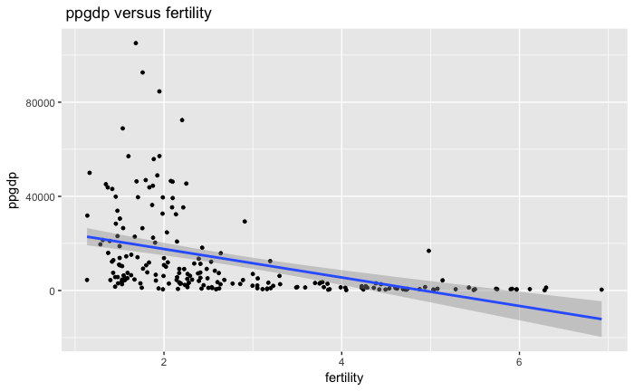

```r
p <- ggplot(data=DB, aes(x= fertility, y= ppgdp)) +
  geom_point(size=1) + geom_smooth(method=lm) + ggtitle(" ppgdp versus fertility ")
p
```

We notice that a straight line mean function is not a plausible for a summary of this graph.

Let’s now draw the scatterplot of log(fertility) versus log(ppgdp) :

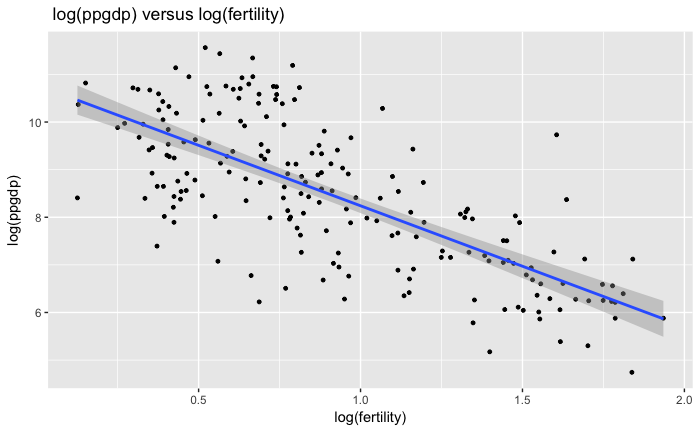

```r
p <- ggplot(data=DB, aes(x= log(fertility), y= log(ppgdp))) +
  geom_point(size=1) + geom_smooth(method=lm) + ggtitle(" log(ppgdp) versus log(fertility) ")
p
```

Now we see that a simple linear regression model is plausible for a summary of this graph.

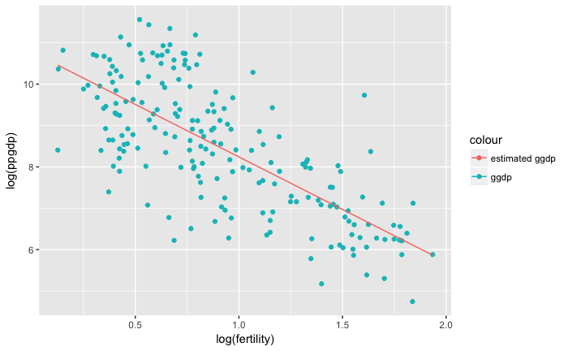

```r
#  Linear Regression : log(ppgdp) ~ log(fertility)
fit_loggdp_logfertility <- lm(log(ppgdp) ~ log(fertility), data=DB)
f<-function(x,a){
  return(a[2]*x+a[1])
}
p <- ggplot(data=DB, aes(x= log(fertility) ) )  + geom_point(aes(y=log(ppgdp), colour = "ggdp")) + geom_line(aes(y = f(log(fertility),fit_loggdp_logfertility$coefficients), colour = "estimated ggdp"))

p
```

```r
RSS_loggdp_logfertility <-sum(residuals(fit_loggdp_logfertility)^2)
RSS_loggdp_logfertility
```

```
[1] 227.7523
```

```r
Var_loggdp_logfertility <- sum( (log(DB$ppgdp) - mean(log(DB$ppgdp)))**2)
fraction_loggdp_logfertility <- 1 - RSS_loggdp_logfertility/Var_loggdp_logfertility
fraction_loggdp_logfertility
```

```
[1] 0.525985
```

```r
DB %>% View()
```

Bosnia and Herzegovina has the lowest fertility Niger has the highiest fertility

```r
head(sort(residuals(fit_loggdp_logfertility)),2)
```

```
North Korea     Moldova
  -2.812794   -2.442884
```

```r
tail(sort(residuals(fit_loggdp_logfertility)),2)
```

```
            Qatar Equatorial Guinea
         2.416462          3.028584
```

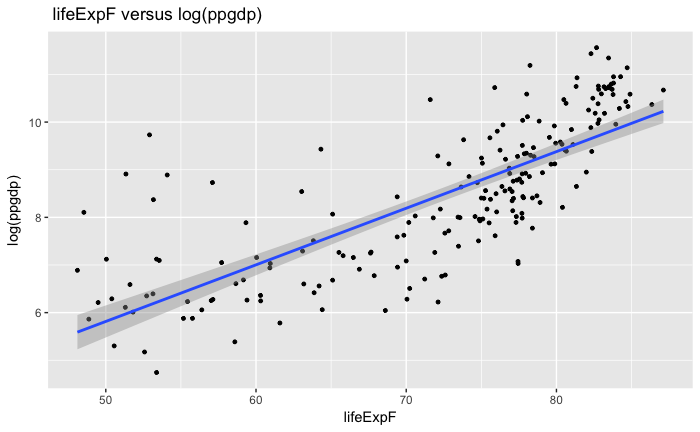

```r
p <- ggplot(data=DB, aes(x= lifeExpF, y= log(ppgdp))) +
  geom_point(size=1) + geom_smooth(method=lm) + ggtitle(" lifeExpF versus log(ppgdp) ")
p
```

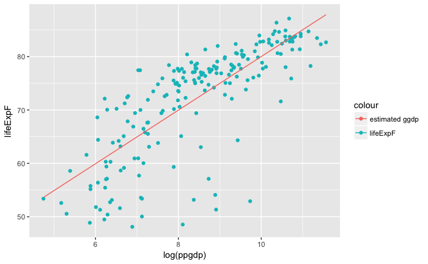

```r
#  Linear Regression
fit_lifeExpF_loggdp <- lm(lifeExpF~log(ppgdp), data=DB)
f<-function(x,a){
  return(a[2]*x+a[1])
}
p <- ggplot(data=DB, aes(x= log(ppgdp) ) ) + geom_point(aes(y=lifeExpF, colour = "lifeExpF")) + geom_line(aes(y = f(log(ppgdp),fit_lifeExpF_loggdp$coefficients), colour = "estimated ggdp"))

p
```